# Project Part 1

**Due dates:** Friday, September 18 at 11:59pm on Canvas.

**Submission:** A template file is provided, with a rough outline: project_1_1_template.qmd

Once you have completed the report, submit *both* your rendered HTML file and the Quarto file to Canvas.

# Overview

This semester, you will complete a project in which you use logistic regression to investigate a research question of your choosing. You will then write a report that communicates the results of your analysis and draws a conclusion about your research question, and finally present your work to me.

This project will be broken into several different parts; I will provide feedback on each part.

- **Part 1** (20 pts): identifying a research question and dataset; EDA to explore the data and variables.
- **Part 2** (35 pts): further EDA; model fitting and diagnostics; inference.
- **Part 3** (45 pts): final report, combining work from parts 1 and 2, and some additional analysis and writing. Also incorporating any changes based on feedback to first two parts.

# Your task in Part 1

For the first part of the project, you will identify a research question and a dataset to address that question, perform exploratory data analysis, and write up your results. You will submit two documents on Canvas for part 1:

- A description of your research question, data, and EDA (.html file):
  - This is the rendered write up that will present your question + EDA
  - There should be **no code** showing. This includes warnings and other stray code output – hide it all.
  - You will be graded on writing as well as your statistical analysis.
- Your Quarto (.qmd) file, with all the code you used for your analysis
  - The goal is that a person who reads your report, and wants to replicate your results, could look at your .qmd file and completely reproduce the results and figures in the rendered report.

Your written report for part 1 will contain four sections: Research question, Data summary, Univariate EDA, and Multivariate EDA. Your goal is to create any visualizations necessary to exploring the data before fitting a model.

There is no minimum or maximum length required. However, your analysis should be thorough, with your report addressing the research question, and containing all the elements described below.

### Research question and data

Come up with a research question that you can answer with data, and find a dataset that allows you to tackle this research question. Provide the questions you want to answer and a citation for the source of the data you will use.

(You may not use any of the datasets we have worked with in class).

**Requirements:**

- The outcome of interest must be a *binary* variable
- The data must contain at least **5** other variables which you think may be related to the outcome of interest, and which help address your research question.
  - At least one of these variables must be categorical
  - At least two of these variables must be quantitative
- Everyone must choose their own data and research question
  - In the unlikely event that two students choose the same data and research question, the first student to submit the assignment will receive priority

### Data summary

Write 1-2 paragraphs which:

- Describe details of the data. What does a row in the data represent? How many rows and columns? What information do the variables record? Are there any missing data?
- Describe any data manipulation. Did you remove any missing values? Did you focus only on a subset of the data? Did you create any new variables?

### Univariate EDA

Choose at least **3** of your available variables that are relevant to the research questions. For each variable: make a plot, calculate any appropriate summary statistics, and discuss the distribution in 2–3 sentences. Make sure to add a title and good labels to each plot. Plots and summary statistics depend on the type of variable.

### Multivariate EDA

Using the variables from Univariate EDA, create one or more plots that allow you to address the research question. You may be able to address the question with a single plot, or you may need to make multiple plots. Calculate any appropriate summary statistics. Use the plot(s) and summary statistics to address the research questions in a 1–2 paragraphs.

# A few ideas for data sources

Here are some ideas for data sources, but you are also welcome to find data elsewhere!

- [CORGIS: The Collection of Really Great, Interesting, Situated Dataset](https://corgis-edu.github.io/corgis/csv/)
- [Awesome Public Datasets](https://github.com/awesomedata/awesome-public-datasets) - large but categorized list by topic and data type
- [Driven Data](https://www.drivendata.org/competitions/)
- You can create data from the US Census Bureau using [tidyCensus](https://walker-data.com/tidycensus/articles/basic-usage.html)
- [Data on Fires in the US and resultant damage](https://www.usfa.fema.gov/statistics/data-sets/)
- [Data Is Plural](https://www.data-is-plural.com/) – Weekly feed (with archive) of interesting datasets
- [AWS Data Exchange - Open Data](https://aws.amazon.com/marketplace/search/results?CONTRACT_TYPE=OPEN_DATA_LICENSES&filters=CONTRACT_TYPE)
- The OpenIntro textbooks have a great [list of datasets](https://www.openintro.org/data/)
- Shonda Kuiper has compiled a [list](https://stat2labs.sites.grinnell.edu/DataResources.html) of different data sources
- The [TidyTuesday](https://github.com/rfordatascience/tidytuesday) project has a long list of many different datasets
- The [nhanesA](https://cran.r-project.org/web/packages/nhanesA/vignettes/Introducing_nhanesA.html) package allows you to explore and retrieve data from the National Health and Nutrition Examination Survey
- [College ScoreCard data](https://collegescorecard.ed.gov/) for many different institutions
- [American time use survey data](https://github.com/swang87/atus)
- [Lahman baseball data](https://cran.r-project.org/web/packages/Lahman/index.html)
- CDC [Behaviorial Risk Factor Surveillance System](https://www.cdc.gov/brfss/) data
- National Park [visitor use statistics](https://irma.nps.gov/Stats/)

# Appearance and style

### Writing

The report should be written like an article or research paper: in full sentences and paragraphs, with headings for each section. You should not write your report with question numbers or as a list of bullet points. Scientific articles are generally written in third person, though “we” can also be acceptable (“we can see from Figure 2.1 …”) in some disciplines.

### Code

As with previous assignments, you will write the document in Quarto. However, in full reports, the only output that should be visible from code chunks are figures and tables. If a code chunk does not produce a figure or table, you can hide it from the knitted document with `include=F`:

````
```{r, include=F}

```
````

If a code chunk produces a figure or table, only the figure or table should be visible in the knitted document. You can hide the chunk but display the output with `echo=F, message=F, warning=F`:

````
```{r, echo=F, message=F, warning=F}

```
````

### Figures

Figures should have labeled axes, and should be clear and easy to read. Figures should also be captioned and numbered; to caption a figure, use `fig.cap = "..."` in the chunk options. For example (scroll to the right on the code to see it all),

````
```{r, echo=F, message=F, warning=F, fig.cap="Figure 2.1: Bill depth vs. bill length for penguins near Palmer Station, Antarctica."}
penguins |>
  ggplot(aes(x = bill_length_mm,
             y = bill_depth_mm)) +
  geom_point() +
  labs(x = "Bill length (mm)",
       y = "Bill depth (mm)") +
  theme_bw()
```
````

is displayed as

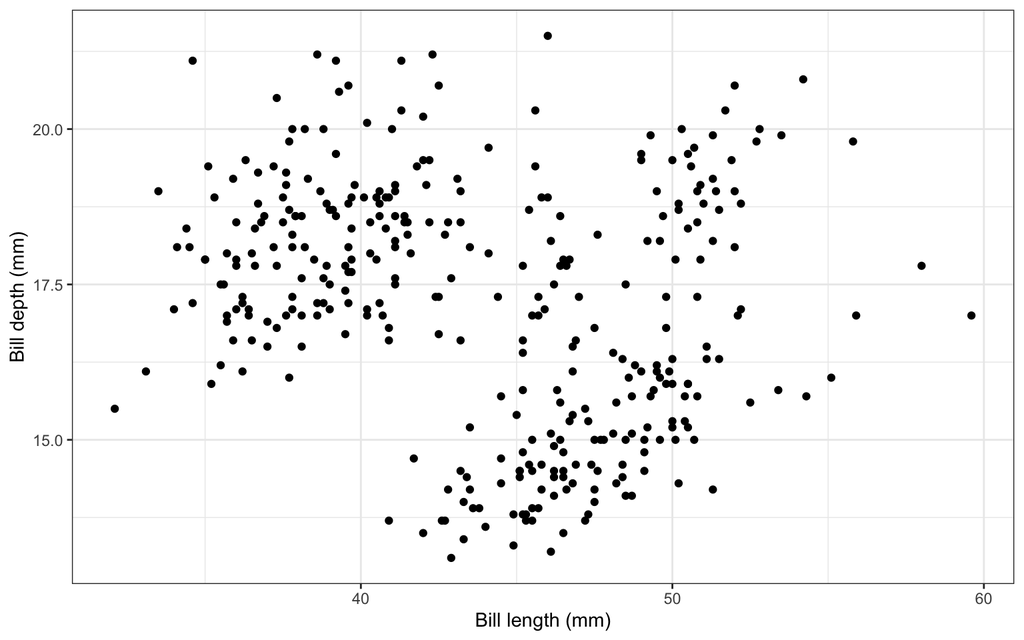

Figure 1: Bill depth vs. bill length for penguins near Palmer Station, Antarctica.

Captions should provide enough information to understand what is being plotted, but interpretation can be left to the main text. Refer to figures by their number in the text. Make sure that any figures you include are discussed in the text.

### Tables

Tables should be nicely formatted, and have a number and caption. This can be done with the `kable` function in the `knitr` package.

For example,

[output not shown]

is displayed as

Table 3.2: Penguins by island and species

|  | Adelie | Chinstrap | Gentoo |
| --- | --- | --- | --- |
| Biscoe | 44 | 0 | 124 |
| Dream | 56 | 68 | 0 |
| Torgersen | 52 | 0 | 0 |

### Writing math in Quarto or R Markdown

Here are some examples of writing math, which you can adapt:

| Math | Code |
| --- | --- |
| $Y_i \sim Bernoulli(\pi_i)$ | `$Y_i \sim Bernoulli(\pi_i)$` |
| $\log \left( \dfrac{\pi_i}{1 - \pi_i} \right)$ | `$\log \left( \dfrac{\pi_i}{1 - \pi_i} \right)$` |
| $\widehat{\pi}_i$ | `$\widehat{\pi}_i$` |

# Checklist

- Change name in Quarto YAML
- Four sections: Research question, Data summary, Univariate EDA, Multivariate EDA
- Research question: a description of the research question you will investigate
  - Chosen data must have binary outcome of interest
  - Chosen data must have at least 5 other variables, including at least one categorical variable and two quantitative variables
- Data Summary:
  - What does a row in the data represent?
  - How many rows and columns are there?
  - What variables are in the data?
  - Are there any missing data?
- Univariate EDA:
  - Pick three variables *relevant to the research question*
  - Plot, appropriate summary statistics, and describe distribution for each variable
- Multivariate EDA:
  - One or more plots that examine the relationships between the three variables from univariate EDA
  - Plots allow you to address the research question
  - Discuss plots in context of research question
- Writing:
  - Each section written as a paragraph, with full sentences
  - No bullet points or lists
- Code:
  - Code is included in the Quarto document, but *not* displayed in the rendered HTML
  - The only R output shown in the report is figures and tables
- Figures:
  - Include meaningful caption and axis labels (see above for details on including a caption)
  - Each figure included in the report is discussed in your writing, and referred to by its figure number
- Submission:
  - Submit *both* the rendered HMTL and the .qmd file to Canvas